# Hw9

Allison Nguyen

2025-04-21

eid: ann2464

github: https://github.com/05alli/SDSHw9

# **Problem 1: Manufacturing flaws in circuit boards**

## **Part A**

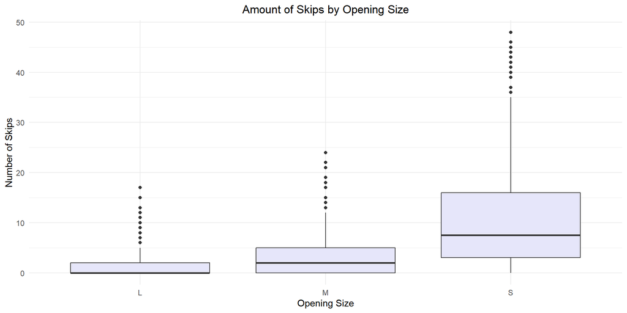

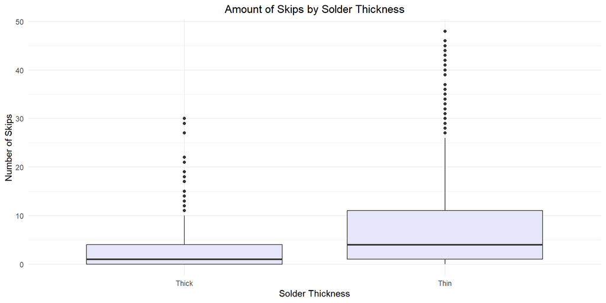

## **Part B**

```
##                     Estimate X95..CI.Lower X95..CI.Upper
## (Intercept)             0.39         -0.63          1.41
## OpeningM                2.41          0.96          3.85
## OpeningS                5.13          3.68          6.57
## SolderThin              2.28          0.84          3.72
## OpeningM:SolderThin    -0.74         -2.78          1.30
## OpeningS:SolderThin     9.65          7.61         11.70
```

## **Part C**

When the opening is Large and the solder is Thick, the expected number of skips is 0.39. Since the 95% confidence interval includes zero, this estimate is not statistically distinguishable from zero.

When the opening is Medium and the solder is Thick, the number of skips increases by approximately 2.41 compared to the baseline, and this effect is statistically significant.

When the opening is Small and the solder is Thick, the number of skips increases by about 5.13, which is highly statistically significant.

When switching to Thin solder while using a Large opening, the number of skips rises by 2.28, and this increase is statistically significant.

For a Medium opening with Thin solder, the combined effect leads to about 0.74 fewer skips than expected from the separate individual effects of Medium opening and Thin solder. This difference is not statistically significant.

For a Small opening with Thin solder, the number of skips rises by an additional 9.65 beyond what the individual effects of Small opening and Thin solder would suggest. This interaction is strongly statistically significant.

## **Part D**

Based on the model, I recommend using a large opening and thick solder, as this combination minimizes the predicted number of skips

# **Problem 2: Grocery store prices**

## **Part A**

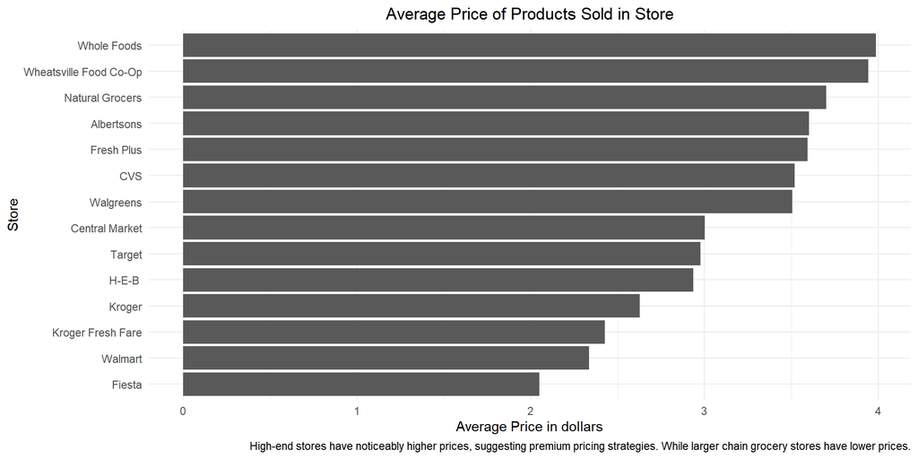

## **Part B**

[figure not shown]

## **Part D**

Whole Foods and Natural Grocers charge the highest prices. While Walmart and Fiesta charge the lowest prices.

## **Part E**

An examination of the estimated coefficients for average product prices reveals that Central Market charges slightly more than HEB. The confidence interval for HEB’s price effect ranges from -0.95 to -0.35, while Central Market’s interval spans from -0.92 to -0.23. Because HEB’s coefficient is more negative, this suggests that HEB generally offers lower prices compared to Central Market, although the difference between the two is relatively small.

## **Part F**

The negative coefficient for Income10K (-0.01) suggests that, on average, shoppers in lower-income ZIP codes tend to pay slightly higher prices for the same product, pointing to a potential regressive pricing trend.

Furthermore, a one-standard deviation increase in ZIP code income is linked to a 0.03 standard-deviation decrease in product price, indicating that as neighborhood income rises, the expected price for the same item tends to decline slightly

# **Problem 3: redlining**

1. True. Figure A1 shows a clear positive relationship between the percentage of minority residents in a ZIP code and the number of FAIR policies. Both Model D1 and Model D2 confirm this relationship is statistically significant, even after adjusting for income. Additionally, Model E further supports this association, with a minority coefficient of 0.008 and a p-value of 0.006, confirming the effect remains significant after controlling for income, fire risk, and housing age.
2. Undecidable. The regression models provided do not include an interaction term between minority percentage and housing age, which would be necessary to evaluate whether the relationship between minority population and FAIR policies varies depending on the age of the housing stock. Without this interaction term, the question cannot be answered with the available evidence.
3. False. Model C directly tests for an interaction between minority percentage and fire risk level. The interaction term (minority:fire_riskLow) is very close to zero (-0.001) and not statistically significant (p = 0.839). This suggests that the relationship between minority percentage and FAIR policies does not differ meaningfully between high and low fire-risk ZIP codes.
4. False. In Model D2, after including both minority percentage and median income as predictors, the coefficient for minority percentage remains positive and statistically significant (p = 0.002). This shows that income does not fully explain the relationship between minority percentage and the number of FAIR policies. If income fully accounted for the association, the minority coefficient would not be significant.
5. True. In Model E, the coefficient for minority percentage is 0.008 with a p-value of 0.006, indicating a statistically significant positive relationship even after controlling for income, fire risk, and housing age. This suggests that the percentage of minority residents is still meaningfully associated with the number of FAIR policies, independent of these other factors.